# Demo: Indexing/Subsetting

NIHES BST02

Eleni-Rosalina Andrinopoulou, Department of Biostatistics, Erasmus Medical Center

15 February 2020

Load packages  
If you are using the package for the first time, you will have to first install it

```r
# install.packages("survival")
library(survival)
```

Select the 3rd element for vector age

```r
pbc$age[3]
```

```
## [1] 70.07
```

Select the 3rd column of the pbc data set

```r
pbc[, 3]
```

```
##   [1] dead       censored   dead       dead       transplant dead       censored   dead       dead       dead       dead       dead
##  [13] censored   dead       dead       censored   dead       dead       censored   dead       censored   dead       dead       dead
##  [25] censored   dead       dead       dead       censored   dead       dead       censored   dead       censored   dead       censored
##  [37] dead       dead       dead       censored   dead       censored   censored   dead       censored   dead       censored   censored
##  [49] dead       dead       dead       dead       dead       dead       dead       dead       dead       censored   dead       censored
##  [61] censored   dead       dead       dead       censored   dead       dead       censored   dead       censored   censored   censored
##  [73] censored   dead       dead       dead       dead       dead       censored   dead       dead       dead       censored   censored
##  [85] dead       dead       dead       censored   dead       dead       dead       dead       censored   dead       dead       censored
##  [97] dead       censored   censored   dead       censored   censored   dead       dead       transplant dead       censored   dead
## [109] censored   dead       transplant dead       dead       dead       censored   censored   dead       dead       dead       transplant
## [121] dead       censored   dead       censored   transplant dead       censored   dead       censored   dead       dead       censored
## [133] dead       censored   censored   censored   censored   dead       censored   censored   censored   dead       dead       dead
## [145] censored   censored   censored   dead       dead       censored   censored   dead       censored   dead       censored   dead
## [157] censored   transplant dead       censored   censored   dead       dead       dead       dead       censored   dead       censored
## [169] dead       censored   censored   censored   censored   censored   censored   dead       censored   censored   censored   censored
```

[output cut: 21 more lines]

```r
pbc[, 3]
```

```
##   [1] dead       censored   dead       dead       transplant dead       censored   dead       dead       dead       dead       dead
##  [13] censored   dead       dead       censored   dead       dead       censored   dead       censored   dead       dead       dead
##  [25] censored   dead       dead       dead       censored   dead       dead       censored   dead       censored   dead       censored
##  [37] dead       dead       dead       censored   dead       censored   censored   dead       censored   dead       censored   censored
##  [49] dead       dead       dead       dead       dead       dead       dead       dead       dead       censored   dead       censored
##  [61] censored   dead       dead       dead       censored   dead       dead       censored   dead       censored   censored   censored
##  [73] censored   dead       dead       dead       dead       dead       censored   dead       dead       dead       censored   censored
##  [85] dead       dead       dead       censored   dead       dead       dead       dead       censored   dead       dead       censored
##  [97] dead       censored   censored   dead       censored   censored   dead       dead       transplant dead       censored   dead
## [109] censored   dead       transplant dead       dead       dead       censored   censored   dead       dead       dead       transplant
## [121] dead       censored   dead       censored   transplant dead       censored   dead       censored   dead       dead       censored
## [133] dead       censored   censored   censored   censored   dead       censored   censored   censored   dead       dead       dead
## [145] censored   censored   censored   dead       dead       censored   censored   dead       censored   dead       censored   dead
## [157] censored   transplant dead       censored   censored   dead       dead       dead       dead       censored   dead       censored
## [169] dead       censored   censored   censored   censored   censored   censored   dead       censored   censored   censored   censored
```

[output cut: 21 more lines]

```r
pbc[[3]]
```

```
##   [1] dead       censored   dead       dead       transplant dead       censored   dead       dead       dead       dead       dead
##  [13] censored   dead       dead       censored   dead       dead       censored   dead       censored   dead       dead       dead
##  [25] censored   dead       dead       dead       censored   dead       dead       censored   dead       censored   dead       censored
##  [37] dead       dead       dead       censored   dead       censored   censored   dead       censored   dead       censored   censored
##  [49] dead       dead       dead       dead       dead       dead       dead       dead       dead       censored   dead       censored
##  [61] censored   dead       dead       dead       censored   dead       dead       censored   dead       censored   censored   censored
##  [73] censored   dead       dead       dead       dead       dead       censored   dead       dead       dead       censored   censored
##  [85] dead       dead       dead       censored   dead       dead       dead       dead       censored   dead       dead       censored
##  [97] dead       censored   censored   dead       censored   censored   dead       dead       transplant dead       censored   dead
## [109] censored   dead       transplant dead       dead       dead       censored   censored   dead       dead       dead       transplant
## [121] dead       censored   dead       censored   transplant dead       censored   dead       censored   dead       dead       censored
## [133] dead       censored   censored   censored   censored   dead       censored   censored   censored   dead       dead       dead
## [145] censored   censored   censored   dead       dead       censored   censored   dead       censored   dead       censored   dead
## [157] censored   transplant dead       censored   censored   dead       dead       dead       dead       censored   dead       censored
## [169] dead       censored   censored   censored   censored   censored   censored   dead       censored   censored   censored   censored
```

[output cut: 21 more lines]

```r
pbc$status
```

```
##   [1] dead       censored   dead       dead       transplant dead       censored   dead       dead       dead       dead       dead
##  [13] censored   dead       dead       censored   dead       dead       censored   dead       censored   dead       dead       dead
##  [25] censored   dead       dead       dead       censored   dead       dead       censored   dead       censored   dead       censored
##  [37] dead       dead       dead       censored   dead       censored   censored   dead       censored   dead       censored   censored
##  [49] dead       dead       dead       dead       dead       dead       dead       dead       dead       censored   dead       censored
##  [61] censored   dead       dead       dead       censored   dead       dead       censored   dead       censored   censored   censored
##  [73] censored   dead       dead       dead       dead       dead       censored   dead       dead       dead       censored   censored
##  [85] dead       dead       dead       censored   dead       dead       dead       dead       censored   dead       dead       censored
##  [97] dead       censored   censored   dead       censored   censored   dead       dead       transplant dead       censored   dead
## [109] censored   dead       transplant dead       dead       dead       censored   censored   dead       dead       dead       transplant
## [121] dead       censored   dead       censored   transplant dead       censored   dead       censored   dead       dead       censored
## [133] dead       censored   censored   censored   censored   dead       censored   censored   censored   dead       dead       dead
## [145] censored   censored   censored   dead       dead       censored   censored   dead       censored   dead       censored   dead
## [157] censored   transplant dead       censored   censored   dead       dead       dead       dead       censored   dead       censored
## [169] dead       censored   censored   censored   censored   censored   censored   dead       censored   censored   censored   censored
```

[output cut: 21 more lines]

Select the sex of the 10th patient

```r
pbc$sex[10]
```

```
## [1] f
## Levels: m f
```

Select the baseline details of the 5th patient

```r
pbc[pbc$id == 5, ]
```

```
##   id time     status trt   age sex ascites hepato spiders edema bili chol albumin copper alk.phos    ast trig platelet protime stage
## 5  5 1504 transplant   2 38.11   f       0      1       1     0  3.4  279    3.53    143      671 113.15   72      136    10.9     3
##   age40higher     ageST
## 5       young -1.209061
```

```r
pbc[pbc$sex == "m", "bili"]
```

```
##  [1] 1.4 0.8 0.6 2.1 1.9 6.0 1.8 0.7 0.6 1.4 7.2 1.6 2.0 1.8 2.3 3.2 3.5 1.3 0.6 1.5 7.3 3.0 2.3 2.4 2.5 4.0 0.9 0.9 2.3 7.1 5.6 4.0 8.6
## [34] 6.6 2.4 1.2 1.3 3.5 0.9 9.5 1.7 1.7 3.0 1.1
```

```r
pbc$bili[pbc$sex == "m"]
```

```
##  [1] 1.4 0.8 0.6 2.1 1.9 6.0 1.8 0.7 0.6 1.4 7.2 1.6 2.0 1.8 2.3 3.2 3.5 1.3 0.6 1.5 7.3 3.0 2.3 2.4 2.5 4.0 0.9 0.9 2.3 7.1 5.6 4.0 8.6
## [34] 6.6 2.4 1.2 1.3 3.5 0.9 9.5 1.7 1.7 3.0 1.1
```

```r
pbc[pbc$sex == "m" | pbc$bili > 5, "age"]
```

```
##   [1] 58.77 70.07 70.56 56.22 53.93 59.95 64.19 55.97 44.52 52.02 54.44 44.95 61.73 33.63 45.80 49.14 50.54 65.76 44.57 43.90 46.63 46.45
##  [23] 49.34 51.92 43.52 51.94 49.83 47.95 67.41 63.26 33.48 46.39 71.89 48.47 51.47 41.15 51.23 52.83 49.66 35.15 67.91 45.82 52.89 41.95
##  [45] 44.23 62.64 51.25 52.29 30.86 61.80 69.94 69.38 59.41 45.76 43.41 53.31 41.36 60.96 37.61 35.79 52.69 56.77 49.76 41.17 36.08 61.24
##  [67] 58.95 33.18 67.49 41.22 78.44 74.52 70.91 55.39 32.50 65.88 58.65 48.94 67.57 50.25 57.20 60.54 35.35 55.99 58.17 33.15 61.00 54.00
##  [89] 53.00 56.00 47.00 53.00 54.00 48.00 36.00 52.00 66.00 41.00 49.00 49.00 50.00 51.00 44.00 41.00 51.00 54.00 49.00 68.00 62.00 42.00
## [111] 54.00
```

```r
pbc$age[pbc$sex == "m" | pbc$bili > 5]
```

```
##   [1] 58.77 70.07 70.56 56.22 53.93 59.95 64.19 55.97 44.52 52.02 54.44 44.95 61.73 33.63 45.80 49.14 50.54 65.76 44.57 43.90 46.63 46.45
##  [23] 49.34 51.92 43.52 51.94 49.83 47.95 67.41 63.26 33.48 46.39 71.89 48.47 51.47 41.15 51.23 52.83 49.66 35.15 67.91 45.82 52.89 41.95
##  [45] 44.23 62.64 51.25 52.29 30.86 61.80 69.94 69.38 59.41 45.76 43.41 53.31 41.36 60.96 37.61 35.79 52.69 56.77 49.76 41.17 36.08 61.24
##  [67] 58.95 33.18 67.49 41.22 78.44 74.52 70.91 55.39 32.50 65.88 58.65 48.94 67.57 50.25 57.20 60.54 35.35 55.99 58.17 33.15 61.00 54.00
##  [89] 53.00 56.00 47.00 53.00 54.00 48.00 36.00 52.00 66.00 41.00 49.00 49.00 50.00 51.00 44.00 41.00 51.00 54.00 49.00 68.00 62.00 42.00
## [111] 54.00
```

Select the first measurement per patient using the `pbcseq` data set

```r
head(pbcseq[tapply(row.names(pbcseq), pbcseq$id, head, 1), ])
```

```
##    id futime     status trt      age sex day ascites hepato spiders edema bili chol albumin alk.phos   ast platelet protime stage visits
## 1   1    400       dead   1 58.76523   f   0       1      1       1   1.0 14.5  261    2.60     1718 138.0      190    12.2     4      1
## 3   2   5169   censored   1 56.44627   f   0       0      1       1   0.0  1.1  302    4.14     7395 113.5      221    10.6     3      1
## 12  3   1012       dead   1 70.07255   m   0       0      0       0   0.5  1.4  176    3.48      516  96.1      151    12.0     4      1
## 16  4   1925       dead   1 54.74059   f   0       0      1       1   0.5  1.8  244    2.54     6122  60.6      183    10.3     4      1
## 23  5   1505 transplant   0 38.10541   f   0       0      1       1   0.0  3.4  279    3.53      671 113.2      136    10.9     3      1
## 29  6   2503       dead   0 66.25873   f   0       0      1       0   0.0  0.8  248    3.98      944  93.0       NA    11.0     3      1
```

Select the last measurement per patient using the `pbcseq` data set

```r
head(pbcseq[tapply(row.names(pbcseq), pbcseq$id, tail, 1), ])
```

```
##    id futime     status trt      age sex  day ascites hepato spiders edema bili chol albumin alk.phos   ast platelet protime stage
## 2   1    400       dead   1 58.76523   f  192       1      1       1   1.0 21.3   NA    2.94     1612   6.2      183    11.2     4
## 11  2   5169   censored   1 56.44627   f 3226       1      1       1   1.0  4.6  237    2.67      669  88.0      100    11.5     3
## 15  3   1012       dead   1 70.07255   m  743       0      0       1   0.5  1.8  185    3.25      447  88.4      109    13.3     4
## 22  4   1925       dead   1 54.74059   f 1824       1      1       1   1.0  5.3  140    1.83      623 131.8      101    17.0     4
## 28  5   1505 transplant   0 38.10541   f 1455       0      1       1   0.5 19.0   91    2.09      377 156.0      101    13.9     4
## 34  6   2503       dead   0 66.25873   f 2453      NA     NA      NA   0.0  0.7   NA    4.20       NA  60.0       NA    10.5     4
##    visits
## 2       2
## 11      9
## 15      4
## 22      7
## 28      6
## 34      6
```

From the vector `age`, select patients that are younger than 30

```r
pbc$age[pbc$age < 30]
```

```
## [1] 28.88 29.56 26.28
```

From the vector `age`, select only `female` patients

```r
pbc$age[pbc$sex == "f"]
```

```
##   [1] 58.77 56.45 54.74 38.11 66.26 55.53 53.06 42.51 70.56 53.71 59.14 45.69 64.65 40.44 52.18 53.93 49.56 59.95 56.28 55.97 45.07 52.02
##  [23] 54.44 44.95 63.88 41.39 41.55 54.00 51.28 52.06 48.62 56.41 61.73 36.63 55.39 46.67 33.63 33.69 48.87 37.58 41.79 45.80 47.43 61.15
##  [45] 53.51 52.09 67.41 39.20 33.62 53.57 40.39 58.38 60.71 46.63 62.91 40.20 51.29 32.61 49.34 56.40 48.85 32.49 38.49 51.92 43.52 51.94
##  [67] 49.83 47.95 46.52 63.26 67.31 56.01 55.83 47.22 52.76 37.28 41.39 52.44 45.61 76.71 36.53 53.92 46.39 48.85 28.88 44.95 56.57 48.96
##  [89] 43.02 34.04 68.51 62.52 50.36 44.06 38.91 41.15 55.46 51.23 42.64 61.07 49.66 48.85 54.26 55.44 45.82 47.18 53.60 44.10 41.95 63.61
## [111] 44.23 62.00 40.55 42.34 42.97 55.96 62.86 46.76 54.08 47.04 55.73 46.10 52.29 51.20 33.86 75.01 30.86 34.99 55.04 49.60 43.56 59.41
## [133] 48.76 36.49 57.37 42.74 58.82 53.50 43.41 41.36 47.75 35.49 48.66 52.67 49.87 30.28 55.57 52.15 41.61 55.45 70.00 43.94 42.57 44.57
## [155] 56.94 40.26 37.61 48.36 70.84 35.79 62.62 50.65 54.53 52.69 52.72 56.77 44.40 29.56 57.04 44.63 35.80 40.72 32.23 41.09 61.64 37.06
## [177] 62.58 48.98 61.99 72.77 61.30 52.62 52.91 47.26 50.20 69.35 41.17 59.16 36.08 34.60 42.71 63.63 56.63 46.26 61.24 38.62 38.77 56.70
## [199] 36.92 62.41 34.61 58.34 50.18 42.69 34.38 33.18 38.38 59.76 66.41 46.79 56.08 41.37 64.57 67.49 44.83 45.77 32.95 41.22 55.42 47.98
## [221] 40.79 56.97 68.46 39.86 35.31 31.44 58.26 51.49 59.97 52.36 42.79 34.87 44.14 46.38 56.31 70.91 55.39 45.08 26.28 50.47 38.40 47.42
## [243] 47.98 38.32 50.11 35.09 32.50 56.15 46.15 65.88 33.94 62.86 48.56 46.35 38.85 58.65 48.94 65.98 40.90 57.20 31.38 52.73 38.09 58.17
## [265] 45.21 37.80 60.66 35.53 43.07 56.39 30.57 61.18 58.30 62.33 38.00 33.15 60.00 65.00 54.00 75.00 62.00 43.00 46.00 44.00 64.00 40.00
## [287] 63.00 34.00 52.00 49.00 54.00 63.00 46.00 53.00 56.00 56.00 55.00 65.00 56.00 47.00 60.00 53.00 54.00 50.00 48.00 36.00 48.00 70.00
## [309] 51.00 54.00 48.00 66.00 53.00 62.00 59.00 39.00 67.00 58.00 64.00 46.00 64.00 41.00 49.00 44.00 59.00 63.00 61.00 64.00 49.00 42.00
## [331] 50.00 51.00 37.00 62.00 51.00 52.00 33.00 60.00 63.00 33.00 51.00 37.00 59.00 55.00 49.00 40.00 67.00 41.00 69.00 52.00 57.00 36.00
## [353] 50.00 64.00 62.00 42.00 44.00 69.00 52.00 66.00 40.00 52.00 46.00 51.00 43.00 39.00 51.00 67.00 35.00 67.00 39.00 57.00 58.00 53.00
```

From the vector `age`, select the 3rd element

```r
pbc$age[3]
```

```
## [1] 70.07
```

```r
pbc[pbc$sex == "m" & pbc$status == 2, ]
```

```
##  [1] id          time        status      trt         age         sex         ascites     hepato      spiders     edema       bili
## [12] chol        albumin     copper      alk.phos    ast         trig        platelet    protime     stage       age40higher ageST
## <0 rows> (or 0-length row.names)
```

```r
pbc[pbc$sex == "m" | pbc$status == 2, ]
```

```
##      id time     status trt   age sex ascites hepato spiders edema bili chol albumin copper alk.phos    ast trig platelet protime stage
## 3     3 1012       dead   1 70.07   m       0      0       0   0.5  1.4  176    3.48    210    516.0  96.10   55      151    12.0     4
## 14   14 1217       dead   2 56.22   m       1      1       0   1.0  0.8   NA    2.27     43    728.0  71.00   NA      156    11.0     4
## 21   21 3445   censored   2 64.19   m       0      1       1   0.0  0.6  252    3.83     41    843.0  65.10   83      336    11.4     4
## 24   24 4079       dead   1 44.52   m       0      1       0   0.0  2.1  456    4.00    124   5719.0 221.88  230       70     9.9     2
## 48   48 4427   censored   2 49.14   m       0      0       0   0.0  1.9  259    3.70    281  10396.8 188.34  178      214    11.0     3
## 52   52 2386       dead   1 50.54   m       0      0       0   0.0  6.0  614    3.70    158   5084.4 206.40   93      362    10.6     1
## 55   55 1360       dead   1 65.76   m       0      0       0   0.0  1.8  416    3.94    121  10165.0  79.98  219      213    11.0     3
## 58   58 4459   censored   1 44.57   m       0      0       0   0.0  0.7  242    4.08     73   5890.0  56.76  118       NA    10.6     1
## 61   61 4256   censored   2 43.90   m       0      0       0   0.0  0.6  216    3.94     28    601.0  60.45  188      211    13.0     1
## 66   66 4191       dead   1 46.45   m       0      1       0   0.0  1.4  427    3.70    105   1909.0 182.90  171      123    11.0     3
## 80   80  890       dead   2 67.41   m       0      1       0   0.0  7.2  247    3.72    269   1303.0 176.70   91      360    11.2     4
## 90   90 2689       dead   1 33.48   m       0      0       0   0.0  1.6  660    4.22     94   1857.0 151.90  155      337    11.0     2
## 97   97  611       dead   2 71.89   m       0      1       0   0.5  2.0  420    3.26     62   3196.0  77.50   91      344    11.4     3
## 99   99 3820   censored   2 48.47   m       0      0       0   0.0  1.8  460    3.35    148   1472.0 108.50  118      172    10.2     2
```

[output cut: 75 more lines]

Select the `serum bilirubin` measurements only for `female` patients  
Calculate the mean and standard deviation  
Plot a histogram

```r
pbc[pbc$sex == "f", "bili"]
```

```
##   [1] 14.5  1.1  1.8  3.4  0.8  1.0  0.3  3.2 12.6  1.4  3.6  0.7  0.8  0.7  2.7 11.4  0.7  5.1  3.4 17.4  0.7  5.2 21.6 17.2  0.7  3.6
##  [27]  4.7  1.8  0.8  0.8  1.2  0.3  7.1  3.3  0.7  1.3  6.8  2.1  1.1  3.3  0.6  5.7  0.5  0.8  1.1  0.8  2.6  1.3  1.1  2.3  0.8  0.9
##  [53]  1.3 22.5  2.1  1.2  1.1  0.7 20.0  0.6  1.2  0.5  0.7  8.4 17.1 12.2  6.6  6.3  0.8 14.4  4.5  1.3  0.4  2.1  5.0  1.1  0.6  2.0
##  [79]  5.0  1.4  1.3  3.2 17.4  1.0  1.0  0.9  0.9  2.5  1.1  1.1  2.1  0.6  0.4  0.5  1.9  5.5  2.0  6.7  0.7  3.0  6.5  3.5  0.6  0.6
## [105]  5.1  1.3  1.2  0.5 16.2  0.9 17.4  2.8  1.9  0.7  0.4  0.8  1.1  1.1  1.1  0.9  1.0  2.9 28.0  0.7  1.2  1.2  7.2  1.0  0.9  0.5
## [131]  0.6 25.5  0.6  3.4  0.6  2.3  3.2  0.3  8.5  5.7  0.4  1.3  1.2  0.5  1.3  3.0  0.5  0.8  3.2  0.9  0.6  1.8  4.7  1.4  0.6  0.5
## [157] 11.0  0.8  2.0 14.0  0.7  1.3  2.3 24.5  0.9 10.8  1.5  3.7  1.4  0.6  0.7  2.1  4.7  0.6  0.5  0.5  0.7  2.5  0.6  0.6  3.9  0.7
## [183]  1.3  1.2  0.5  0.9  5.9  0.5 11.4  0.5  1.6  3.8  0.9  4.5 14.1  1.0  0.7  0.5  0.7  4.5  3.3  3.4  0.4  0.9  0.9 13.0  1.5  1.6
## [209]  0.6  0.8  0.4  4.4  1.9  8.0  3.9  0.6  2.1  6.1  0.8  1.3  0.6  0.5  1.1  3.1  0.7  1.1  0.5  1.1  3.1  3.2  2.8  1.1  3.4  3.5
## [235]  0.5  6.6  6.4  3.6  1.0  1.0  0.5  2.2  1.6  2.2  1.0  1.0  5.6  0.5  1.6 17.9  1.3  1.1  1.3  0.8  2.0  6.4  8.7  1.4  3.2  8.5
## [261]  0.8  1.1  2.4  5.2  1.0  0.7  1.0  0.5  2.9  0.6  0.8  0.4  0.4  1.7  2.0  6.4  0.7  1.4  0.7  0.7  0.8  0.7  5.0  0.4  1.1  0.6
## [287]  0.6  1.8  1.5  1.2  1.0  0.7  3.1 12.6  2.8  7.1  0.6  2.1  1.8 16.0  0.6  5.4  9.0  0.9 11.1  8.9  0.5  0.6  3.4  1.4  2.1 15.0
## [313]  0.6  1.3  1.3  1.6  2.2  3.0  0.8  0.8  1.8  5.5 18.0  0.6  2.7  0.9  1.3  1.1 13.8  4.4 16.0  7.3  0.6  0.7  0.7  1.7  2.2  1.8
## [339]  3.3  2.9 14.0  0.8  1.3  0.7 13.6  0.9  0.7  1.2  0.4  0.7  2.0  1.4  1.6  0.5  7.3  8.1  0.5  4.2  0.8  2.5  4.6  1.0  4.5  1.9
## [365]  0.7  1.5  0.6  1.0  0.7  1.2  0.9  1.6  0.8  0.7
```

```r
mean(pbc[pbc$sex == "f", "bili"])
```

```
## [1] 3.262567
```

```r
sd(pbc[pbc$sex == "f", "bili"])
```

```
## [1] 4.591388
```

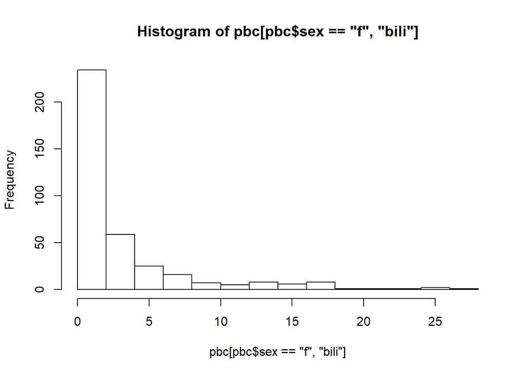

```r
hist(pbc[pbc$sex == "f", "bili"])
```

Select all rows where the `serum bilirubin` measurements are smaller that 10

```r
pbc[pbc$bili < 10, ]
```

```
##    id time     status trt   age sex ascites hepato spiders edema bili chol albumin copper alk.phos    ast trig platelet protime stage
## 2   2 4500   censored   1 56.45   f       0      1       1   0.0  1.1  302    4.14     54   7394.8 113.52   88      221    10.6     3
## 3   3 1012       dead   1 70.07   m       0      0       0   0.5  1.4  176    3.48    210    516.0  96.10   55      151    12.0     4
## 4   4 1925       dead   1 54.74   f       0      1       1   0.5  1.8  244    2.54     64   6121.8  60.63   92      183    10.3     4
## 5   5 1504 transplant   2 38.11   f       0      1       1   0.0  3.4  279    3.53    143    671.0 113.15   72      136    10.9     3
## 6   6 2503       dead   2 66.26   f       0      1       0   0.0  0.8  248    3.98     50    944.0  93.00   63       NA    11.0     3
## 7   7 1832   censored   2 55.53   f       0      1       0   0.0  1.0  322    4.09     52    824.0  60.45  213      204     9.7     3
## 8   8 2466       dead   2 53.06   f       0      0       0   0.0  0.3  280    4.00     52   4651.2  28.38  189      373    11.0     3
## 9   9 2400       dead   1 42.51   f       0      0       1   0.0  3.2  562    3.08     79   2276.0 144.15   88      251    11.0     2
## 11 11 3762       dead   2 53.71   f       0      1       1   0.0  1.4  259    4.16     46   1104.0  79.05   79      258    12.0     4
## 12 12  304       dead   2 59.14   f       0      0       1   0.0  3.6  236    3.52     94    591.0  82.15   95       71    13.6     4
## 13 13 3577   censored   2 45.69   f       0      0       0   0.0  0.7  281    3.85     40   1181.0  88.35  130      244    10.6     3
## 14 14 1217       dead   2 56.22   m       1      1       0   1.0  0.8   NA    2.27     43    728.0  71.00   NA      156    11.0     4
## 15 15 3584       dead   1 64.65   f       0      0       0   0.0  0.8  231    3.87    173   9009.8 127.71   96      295    11.0     3
## 16 16 3672   censored   2 40.44   f       0      0       0   0.0  0.7  204    3.66     28    685.0  72.85   58      198    10.8     3
```

[output cut: 78 more lines]

Make a boxplot of `serum bilirubin` per `sex` using the previous selection

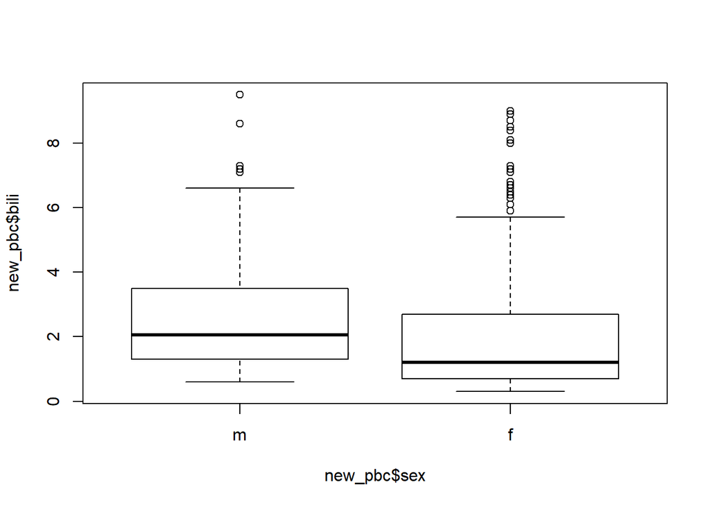

```r
new_pbc <- pbc[pbc$bili < 10, ]
boxplot(new_pbc$bili ~ new_pbc$sex)
```

Create a list with 3 elements:  
1st element: all `pbc$id`  
2nd element: `pbc$bili` for males  
3rd element: `pbc$age` > 30

```r
myList <- list(pbc$id, pbc$bili[pbc$sex == "m"], pbc$age[pbc$age > 30])
```

Select the second element (the output should be a list)

```r
myList[2]
```

```
## [[1]]
##  [1] 1.4 0.8 0.6 2.1 1.9 6.0 1.8 0.7 0.6 1.4 7.2 1.6 2.0 1.8 2.3 3.2 3.5 1.3 0.6 1.5 7.3 3.0 2.3 2.4 2.5 4.0 0.9 0.9 2.3 7.1 5.6 4.0 8.6
## [34] 6.6 2.4 1.2 1.3 3.5 0.9 9.5 1.7 1.7 3.0 1.1
```

Select the third element (the output should be a vector)

```r
myList[[3]]
```

```
##   [1] 58.77 56.45 70.07 54.74 38.11 66.26 55.53 53.06 42.51 70.56 53.71 59.14 45.69 56.22 64.65 40.44 52.18 53.93 49.56 59.95 64.19 56.28
##  [23] 55.97 44.52 45.07 52.02 54.44 44.95 63.88 41.39 41.55 54.00 51.28 52.06 48.62 56.41 61.73 36.63 55.39 46.67 33.63 33.69 48.87 37.58
##  [45] 41.79 45.80 47.43 49.14 61.15 53.51 52.09 50.54 67.41 39.20 65.76 33.62 53.57 44.57 40.39 58.38 43.90 60.71 46.63 62.91 40.20 46.45
##  [67] 51.29 32.61 49.34 56.40 48.85 32.49 38.49 51.92 43.52 51.94 49.83 47.95 46.52 67.41 63.26 67.31 56.01 55.83 47.22 52.76 37.28 41.39
##  [89] 52.44 33.48 45.61 76.71 36.53 53.92 46.39 48.85 71.89 48.47 51.47 44.95 56.57 48.96 43.02 34.04 68.51 62.52 50.36 44.06 38.91 41.15
## [111] 55.46 51.23 52.83 42.64 61.07 49.66 48.85 54.26 35.15 67.91 55.44 45.82 52.89 47.18 53.60 44.10 41.95 63.61 44.23 62.00 40.55 62.64
## [133] 42.34 42.97 55.96 62.86 51.25 46.76 54.08 47.04 55.73 46.10 52.29 51.20 33.86 75.01 30.86 61.80 34.99 55.04 69.94 49.60 69.38 43.56
## [155] 59.41 48.76 36.49 45.76 57.37 42.74 58.82 53.50 43.41 53.31 41.36 60.96 47.75 35.49 48.66 52.67 49.87 30.28 55.57 52.15 41.61 55.45
## [177] 70.00 43.94 42.57 44.57 56.94 40.26 37.61 48.36 70.84 35.79 62.62 50.65 54.53 52.69 52.72 56.77 44.40 57.04 44.63 35.80 40.72 32.23
## [199] 41.09 61.64 37.06 62.58 48.98 61.99 72.77 61.30 52.62 49.76 52.91 47.26 50.20 69.35 41.17 59.16 36.08 34.60 42.71 63.63 56.63 46.26
## [221] 61.24 38.62 38.77 56.70 58.95 36.92 62.41 34.61 58.34 50.18 42.69 34.38 33.18 38.38 59.76 66.41 46.79 56.08 41.37 64.57 67.49 44.83
## [243] 45.77 32.95 41.22 55.42 47.98 40.79 56.97 68.46 78.44 39.86 35.31 31.44 58.26 51.49 59.97 74.52 52.36 42.79 34.87 44.14 46.38 56.31
## [265] 70.91 55.39 45.08 50.47 38.40 47.42 47.98 38.32 50.11 35.09 32.50 56.15 46.15 65.88 33.94 62.86 48.56 46.35 38.85 58.65 48.94 67.57
## [287] 65.98 40.90 50.25 57.20 60.54 35.35 31.38 55.99 52.73 38.09 58.17 45.21 37.80 60.66 35.53 43.07 56.39 30.57 61.18 58.30 62.33 38.00
## [309] 33.15 60.00 65.00 54.00 75.00 62.00 43.00 46.00 44.00 61.00 64.00 40.00 63.00 34.00 52.00 49.00 54.00 63.00 54.00 46.00 53.00 56.00
## [331] 56.00 55.00 65.00 56.00 47.00 60.00 53.00 54.00 50.00 48.00 36.00 48.00 70.00 51.00 52.00 54.00 48.00 66.00 53.00 62.00 59.00 39.00
## [353] 67.00 58.00 64.00 46.00 64.00 41.00 49.00 44.00 59.00 63.00 61.00 64.00 49.00 42.00 50.00 51.00 37.00 62.00 51.00 52.00 44.00 33.00
## [375] 60.00 63.00 33.00 41.00 51.00 37.00 59.00 55.00 54.00 49.00 40.00 67.00 68.00 41.00 69.00 52.00 57.00 36.00 50.00 64.00 62.00 42.00
## [397] 44.00 69.00 52.00 66.00 40.00 52.00 46.00 54.00 51.00 43.00 39.00 51.00 67.00 35.00 67.00 39.00 57.00 58.00 53.00
```

Select the third element (the output should be a vector)  
Then, from the third element, select the elements that are smaller than 20

```r
newData <- myList[[3]]
newData[newData < 20]
```

```
## numeric(0)
```

Create a list with 3 elements and add names:  
1st element - all_id: all `pbc$id`  
2nd element - bili_male: `pbc$bili` for males  
3rd element - young: `pbc$age` < 30

```r
myList <- list(all_id = pbc$id, bili_male = pbc$bili[pbc$sex == "m"], young = pbc$age[pbc$age < 30])
```

Select all_id by name indexing

```r
myList$all_id
```

```
##   [1]   1   2   3   4   5   6   7   8   9  10  11  12  13  14  15  16  17  18  19  20  21  22  23  24  25  26  27  28  29  30  31  32  33
##  [34]  34  35  36  37  38  39  40  41  42  43  44  45  46  47  48  49  50  51  52  53  54  55  56  57  58  59  60  61  62  63  64  65  66
##  [67]  67  68  69  70  71  72  73  74  75  76  77  78  79  80  81  82  83  84  85  86  87  88  89  90  91  92  93  94  95  96  97  98  99
## [100] 100 101 102 103 104 105 106 107 108 109 110 111 112 113 114 115 116 117 118 119 120 121 122 123 124 125 126 127 128 129 130 131 132
## [133] 133 134 135 136 137 138 139 140 141 142 143 144 145 146 147 148 149 150 151 152 153 154 155 156 157 158 159 160 161 162 163 164 165
## [166] 166 167 168 169 170 171 172 173 174 175 176 177 178 179 180 181 182 183 184 185 186 187 188 189 190 191 192 193 194 195 196 197 198
## [199] 199 200 201 202 203 204 205 206 207 208 209 210 211 212 213 214 215 216 217 218 219 220 221 222 223 224 225 226 227 228 229 230 231
## [232] 232 233 234 235 236 237 238 239 240 241 242 243 244 245 246 247 248 249 250 251 252 253 254 255 256 257 258 259 260 261 262 263 264
## [265] 265 266 267 268 269 270 271 272 273 274 275 276 277 278 279 280 281 282 283 284 285 286 287 288 289 290 291 292 293 294 295 296 297
## [298] 298 299 300 301 302 303 304 305 306 307 308 309 310 311 312 313 314 315 316 317 318 319 320 321 322 323 324 325 326 327 328 329 330
## [331] 331 332 333 334 335 336 337 338 339 340 341 342 343 344 345 346 347 348 349 350 351 352 353 354 355 356 357 358 359 360 361 362 363
## [364] 364 365 366 367 368 369 370 371 372 373 374 375 376 377 378 379 380 381 382 383 384 385 386 387 388 389 390 391 392 393 394 395 396
## [397] 397 398 399 400 401 402 403 404 405 406 407 408 409 410 411 412 413 414 415 416 417 418
```